# Valentine’s Consumer Spending Trends

The National Retail Federation in the United States conducts surveys and has created a Valentine’s Day Data Center to explore the data on how consumers celebrate. The NRF has surveyed consumers about how they plan to celebrate Valentine’s Day annually for over a decade.

More information about the dataset can be found here:https://github.com/rfordatascience/tidytuesday/tree/main/data/2024/2024-02-13

**Question:**

1. Which factors (spending categories) most strongly influence overall Valentine’s Day spending patterns?
2. What distinct spending behavior profiles exist among people based on their spending categories, and how do these profiles correlate with age groups?

**Introduction:** I am working with two datasets related to Valentine’s Day consumer behavior to address the research questions. These datasets include Valentine’s historical spending and spending patterns categorized by age.

To address the first question, “Which spending categories most significantly influence overall Valentine’s Day spending patterns?”, I used the historical_spending dataset. This dataset includes numeric variables representing the average percentage spent on each category: Candy, Flowers, Jewelry, Greeting Cards, Evening Out, Clothing, and Gift Cards.

To answer the second question, “What distinct spending behavior profiles exist based on spending categories, and how do these profiles relate to age groups?”, I analyzed the gifts_age dataset. This dataset includes the variables Age, Candy, Flowers, Jewelry, Greeting Cards, Evening Out, Clothing, and Gift Cards. Here, Age is a categorical variable divided into six age groups for individuals aged 18 and older.

**Approach:** First, I conducted a descriptive analysis for both datasets using the summary function to understand the data. Next, I transformed the gifts_age dataset from wide to long format. To explore the gifts_age dataset further, I created a combination of bar and scatter plots, with bars representing spending categories and black dots indicating the overall average spending for each age group.

To address the first research question, “Which factors (spending categories) most strongly influence overall Valentine’s Day spending patterns?”, I performed a Principal Component Analysis (PCA). I visualized the results using a rotation plot matrix to understand how each spending category contributes to overall spending patterns.

For the second question, “What distinct spending behavior profiles exist among people based on their spending categories, and how do these profiles correlate with age groups?”, I applied clustering. I started by creating an elbow plot to determine the optimal number of clusters. Then, I scaled the gifts_age dataset and performed PCA before generating the clusters. Finally, I created two scatter plots for PC1 vs. PC2: the first visualized clusters, and the second displayed age groups, using cluster colors to compare the distributions of spending profiles and age groups.

**Analysis:**

```r
# descriptive analysis
summary(historical_spending)
```

```
##       Year      PercentCelebrating   PerPerson         Candy
##  Min.   :2010   Min.   :51.00      Min.   :103.0   Min.   : 8.60
##  1st Qu.:2013   1st Qu.:54.00      1st Qu.:131.0   1st Qu.:10.85
##  Median :2016   Median :55.00      Median :142.3   Median :12.70
##  Mean   :2016   Mean   :55.46      Mean   :144.4   Mean   :12.84
##  3rd Qu.:2019   3rd Qu.:58.00      3rd Qu.:162.0   3rd Qu.:14.12
##  Max.   :2022   Max.   :60.00      Max.   :196.3   Max.   :17.30
##     Flowers         Jewelry      GreetingCards     EveningOut
##  Min.   :12.33   Min.   :21.52   Min.   :5.910   Min.   :21.39
##  1st Qu.:13.49   1st Qu.:30.34   1st Qu.:7.310   1st Qu.:25.66
##  Median :14.78   Median :30.94   Median :7.870   Median :27.48
##  Mean   :14.65   Mean   :32.55   Mean   :7.676   Mean   :27.47
##  3rd Qu.:15.42   3rd Qu.:34.10   3rd Qu.:8.320   3rd Qu.:28.46
##  Max.   :16.71   Max.   :45.75   Max.   :9.010   Max.   :33.46
##     Clothing       GiftCards
##  Min.   :10.42   Min.   : 8.42
##  1st Qu.:12.00   1st Qu.:10.23
##  Median :14.04   Median :11.04
##  Mean   :14.94   Mean   :11.50
##  3rd Qu.:16.08   3rd Qu.:12.52
##  Max.   :21.46   Max.   :17.22
```

```r
summary(gifts_age)
```

```
##      Age            SpendingCelebrating     Candy         Flowers
##  Length:6           Min.   :13.00       Min.   :42.0   Min.   :25.00
##  Class :character   1st Qu.:18.25       1st Qu.:52.0   1st Qu.:33.25
##  Mode  :character   Median :25.00       Median :59.0   Median :39.00
##                     Mean   :28.67       Mean   :57.0   Mean   :38.17
##                     3rd Qu.:37.75       3rd Qu.:61.5   3rd Qu.:43.25
##                     Max.   :51.00       Max.   :70.0   Max.   :50.00
##     Jewelry      GreetingCards     EveningOut       Clothing
##  Min.   : 8.00   Min.   :33.00   Min.   :24.00   Min.   :12.00
##  1st Qu.:14.75   1st Qu.:35.25   1st Qu.:29.25   1st Qu.:19.25
##  Median :24.50   Median :42.00   Median :30.50   Median :23.00
##  Mean   :22.83   Mean   :39.50   Mean   :32.00   Mean   :22.83
##  3rd Qu.:32.00   3rd Qu.:42.75   3rd Qu.:35.50   3rd Qu.:26.75
##  Max.   :34.00   Max.   :44.00   Max.   :41.00   Max.   :33.00
##    GiftCards
##  Min.   :19.00
##  1st Qu.:20.00
##  Median :21.00
##  Mean   :21.17
##  3rd Qu.:22.75
##  Max.   :23.00
```

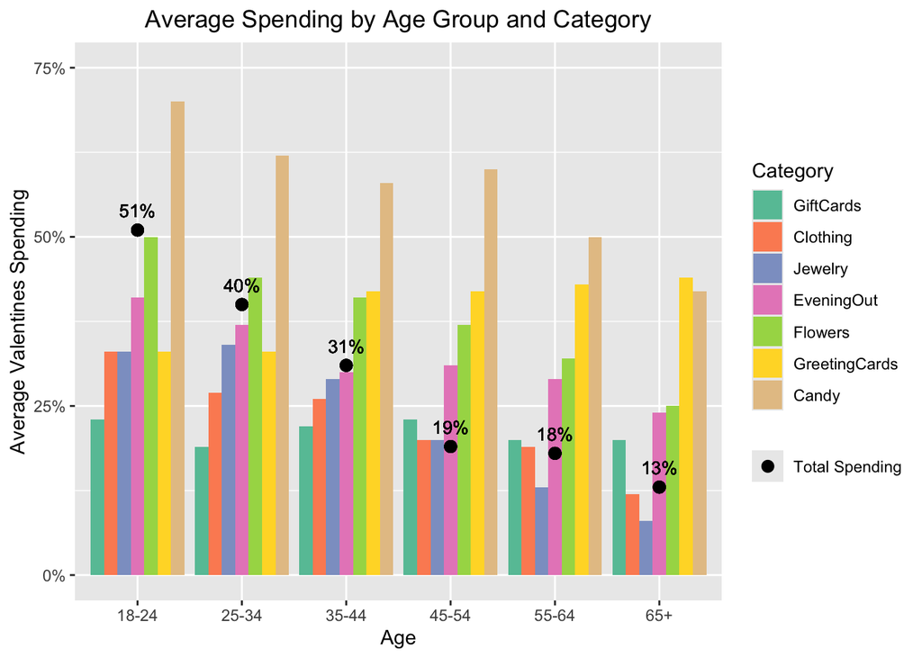

```r
# Data Exploration with bar and scatter plot
gifts_age %>%
  pivot_longer(cols = c(Candy, Flowers, Jewelry, GreetingCards, EveningOut, Clothing, GiftCards),
               names_to = "Category",
               values_to = "AveragePercentSpending") %>%
  mutate(Category = fct_reorder(Category, AveragePercentSpending)) %>%
  ggplot() +
  geom_col(aes(x = Age, y = AveragePercentSpending, fill = Category),
           position = "dodge") +
  geom_point(aes(x = Age , y = SpendingCelebrating, shape = "Total Spending"), size = 3, color = "black") +
  geom_text(aes(x = Age , y = SpendingCelebrating, label = paste0(SpendingCelebrating, "%"), hjust = 0.5, vjust = - 1), size = 3.5) +
  ggtitle("Average Spending by Age Group and Category") +
  scale_fill_brewer(palette = "Set2") +
  scale_shape_manual(values = 16, name = NULL, labels = "Total Spending") +  # Legend for black dot
  scale_y_continuous(name = "Average Valentines Spending",
                     limits = c(0,75),
                     breaks = c(0, 25, 50, 75),
                     labels = c("0%", "25%", "50%", "75%")) +
  theme(plot.title = element_text(hjust = 0.5))
```

```r
# PCA for historical spending
pca_fit <- historical_spending %>%
  select(-c(Year,PercentCelebrating, PerPerson)) %>%
  scale() %>%                   # scale to zero mean and unit variance
  prcomp()
pca_fit
```

```
## Standard deviations (1, .., p=7):
## [1] 2.2092949 0.9625109 0.8477643 0.5008272 0.3581260 0.2852280 0.1159622
##
## Rotation (n x k) = (7 x 7):
##                     PC1          PC2          PC3         PC4         PC5
## Candy         0.4302771  0.152704724  0.034839977  0.14051920  0.44863617
## Flowers       0.4188116 -0.034560623  0.207683257  0.60022763 -0.03262447
## Jewelry       0.4119612 -0.246498912  0.241006189  0.08037922 -0.69658620
## GreetingCards 0.2710915 -0.009214882 -0.938829857  0.14759194 -0.12698872
## EveningOut    0.2490472 -0.840987195 -0.013527570 -0.32880108  0.32520431
## Clothing      0.4220460  0.303885714  0.126142890 -0.07043002  0.36653043
## GiftCards     0.3951058  0.339166941  0.008563498 -0.69185722 -0.23706619
##                       PC6         PC7
## Candy          0.72246069 -0.21762253
## Flowers       -0.47956524 -0.43468347
## Jewelry        0.31628428  0.34599624
## GreetingCards -0.04206019  0.07310556
## EveningOut    -0.12125426 -0.04429973
## Clothing      -0.33009971  0.68216411
## GiftCards     -0.15031469 -0.41391128
```

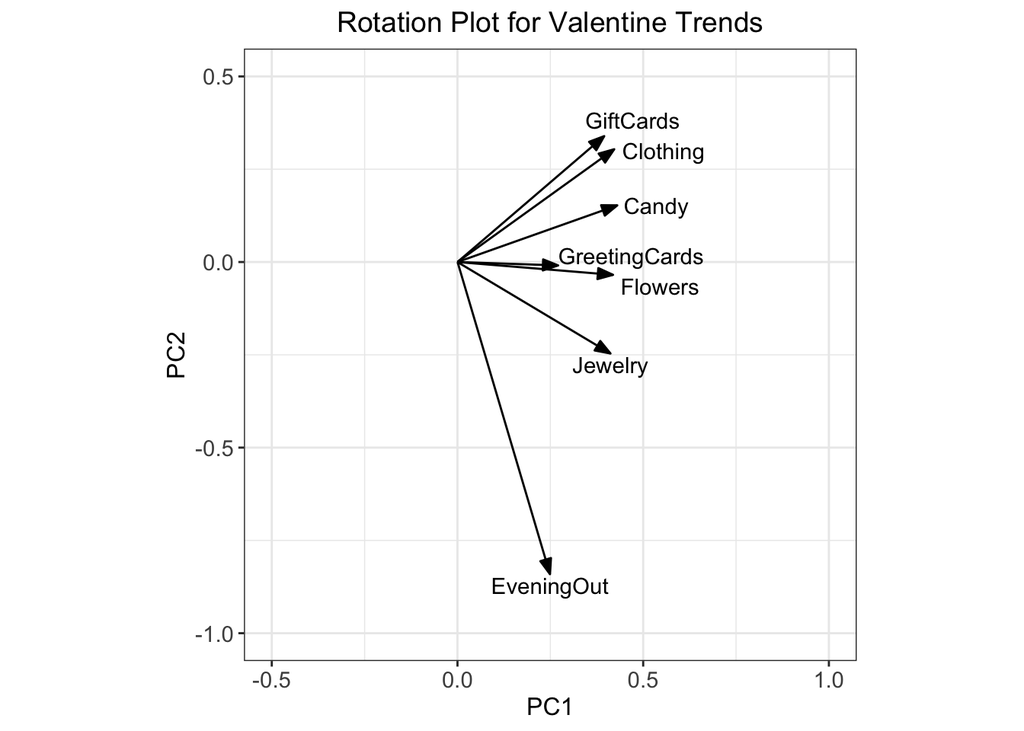

```r
arrow_style <- arrow(
  angle = 20, length = grid::unit(8, "pt"),
  ends = "first", type = "closed"
)
pca_fit %>%
  tidy(matrix = "rotation") %>%
  pivot_wider(
    names_from = "PC", values_from = "value",
    names_prefix = "PC"
  ) %>%
  ggplot(aes(PC1, PC2)) +
  geom_segment(
    xend = 0, yend = 0,
    arrow = arrow_style
  ) +
  geom_text(aes(label = column), vjust = c(0.5, 1.2, 1.2, -0.1, 1.2, 0.6, -0.5), hjust = c(-0.1, -0.1, 0.5, 0 , 0.5, -0.1, 0.2)) +
  xlim(-0.5, 1) + ylim(-1, 0.5) +
  coord_fixed() +
  ggtitle("Rotation Plot for Valentine Trends") +
  theme_bw() +
  theme(axis.title = element_text(size = 12), # Increase axis title size
        axis.text = element_text(size = 11), # Increase axis text size
        plot.title = element_text(size = 14, hjust = 0.5)) # Center plot title
```

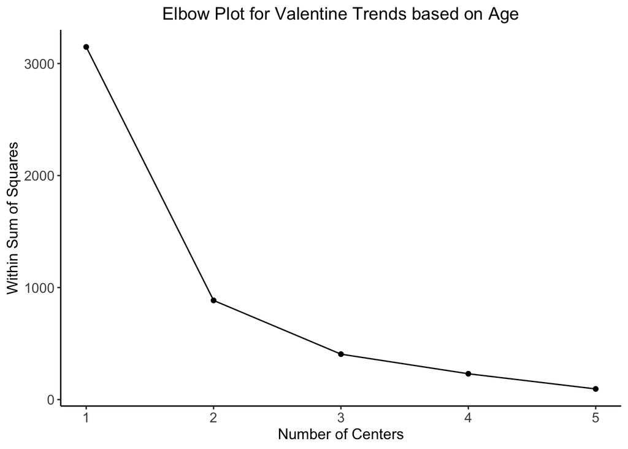

```r
# elbow plot
calc_withinss <- function(data, centers) {
  km_fit <- select(data, where(is.numeric)) %>%
    kmeans(centers = centers, nstart = 10)
  km_fit$tot.withinss
}
tibble(centers = 1:5) %>%
  mutate(
    within_sum_squares = map_dbl(
      centers, ~calc_withinss(gifts_age, .x)
    )
  ) %>%
  ggplot() +
  aes(centers, within_sum_squares) +
  geom_point() +
  geom_line() +
  ggtitle("Elbow Plot for Valentine Trends based on Age") +
  scale_x_continuous(name = "Number of Centers") +
  scale_y_continuous(name = "Within Sum of Squares") +
  theme_classic() +
  theme(axis.title = element_text(size = 12), # Increase axis title size
        axis.text = element_text(size = 11), # Increase axis text size
        plot.title = element_text(size = 14, hjust = 0.5)) # Center plot title
```